# HW_Assignment_1

Arman Aghamyan

January 26, 2019

# Homework 1

*For this Homework, you are required to submit Markdown file (not pdf) with your answers and code in it. Be sure that the file is working, so when I run it, there would be no errors. Write your code and interpretations under each question. The interpretations of the results need to be written below or above all the charts, summaries, or tables. Do not remove problems from your Markdown file. Use the library ggplot2 to solve these problems.*

Use Dataset_1.csv dataset uploaded on Moodle to analyze the relationship between characteristics of newborn babies and their parents. The description of the variables is given with a separate file. Pay great attention to the names of axes, titles, and labels: convert 0-1 to yes-no, where it is appropriate.

Problem 1. (1 pt) Understand the structure of data. Clean the data if it is necessary.

```r
Data<-read.csv('Dataset_1.csv')
Data
```

```
##       id headcir length bweight gestation smoker motherage mnocig mheight
## 1    431      12     19     4.2        33      1        20      7      63
## 2    300      12     18     4.5        35      1        41      7      65
## 3  15648      12     16     4.7        33      1        36     18      66
## 4  15650      12     17     4.8        33      1        37     17      65
## 5  15652      12     16     4.9        34      1        28     15      64
## 6  25656      13     17     4.9        36      1        36     10      64
## 7  15656      12     17     5.0        36      1        25      8      64
## 8  25652      13     17     5.1        37      1        36     30      63
## 9  15654      13     17     5.1        35      1        23      9      65
## 10  1363      12     19     5.2        37      1        37      7      64
## 11 25646      12     17     5.4        36      1        38     10      62
## 12   569      13     19     5.5        39      1        34      7      62
## 13    27      14     20     6.0        41      1        37     25      63
## 14  1272      12     20     6.0        40      1        37      4      62
```

[output cut: 83 more lines]

```r
library(dplyr)
```

```r
library(ggplot2)
str(Data)
```

```
## 'data.frame':    48 obs. of  17 variables:
##  $ id            : int  431 300 15648 15650 15652 25656 15656 25652 15654 1363 ...
##  $ headcir       : int  12 12 12 12 12 13 12 13 13 12 ...
##  $ length        : int  19 18 16 17 16 17 17 17 17 19 ...
##  $ bweight       : num  4.2 4.5 4.7 4.8 4.9 4.9 5 5.1 5.1 5.2 ...
##  $ gestation     : int  33 35 33 33 34 36 36 37 35 37 ...
##  $ smoker        : int  1 1 1 1 1 1 1 1 1 1 ...
##  $ motherage     : int  20 41 36 37 28 36 25 36 23 37 ...
##  $ mnocig        : int  7 7 18 17 15 10 8 30 9 7 ...
##  $ mheight       : int  63 65 66 65 64 64 64 63 65 64 ...
##  $ mppwt         : int  109 125 131 124 139 124 134 119 139 104 ...
##  $ fage          : int  20 37 19 22 24 34 26 24 37 20 ...
##  $ fedyrs        : int  10 14 13 13 11 15 13 13 13 10 ...
##  $ fnocig        : int  35 25 20 19 17 15 10 35 11 35 ...
##  $ bined_weight  : int  5 5 5 5 5 5 5 5 5 5 ...
##  $ lowbwt        : int  1 1 1 1 1 1 1 1 1 1 ...
##  $ mage35        : int  0 1 1 1 0 1 0 1 0 1 ...
##  $ LowBirthWeight: Factor w/ 2 levels "Low","Normal": 1 1 1 1 1 1 1 1 1 1 ...
```

```r
any(is.na(Data))#checking NA's,there no NA
```

```
## [1] FALSE
```

```r
any(duplicated(Data$id))#checking if there are any duplicate values in this column
```

```
## [1] FALSE
```

```r
Data<-select(Data,-c(id))# we don't need this column as each row is unique


#changing the type of variables from int to factors and labels from numeric values into characters
Data$smoker<-factor(Data$smoker)
levels(Data$smoker)<-c("non-smoker","smoker")
Data$bined_weight<-factor(Data$bined_weight)
Data$mage35<-factor(Data$mage35)
levels(Data$mage35)<-c("ageunder35","ageover35")
str(Data)
```

```
## 'data.frame':    48 obs. of  16 variables:
##  $ headcir       : int  12 12 12 12 12 13 12 13 13 12 ...
##  $ length        : int  19 18 16 17 16 17 17 17 17 19 ...
##  $ bweight       : num  4.2 4.5 4.7 4.8 4.9 4.9 5 5.1 5.1 5.2 ...
##  $ gestation     : int  33 35 33 33 34 36 36 37 35 37 ...
##  $ smoker        : Factor w/ 2 levels "non-smoker","smoker": 2 2 2 2 2 2 2 2 2 2 ...
##  $ motherage     : int  20 41 36 37 28 36 25 36 23 37 ...
##  $ mnocig        : int  7 7 18 17 15 10 8 30 9 7 ...
##  $ mheight       : int  63 65 66 65 64 64 64 63 65 64 ...
##  $ mppwt         : int  109 125 131 124 139 124 134 119 139 104 ...
##  $ fage          : int  20 37 19 22 24 34 26 24 37 20 ...
##  $ fedyrs        : int  10 14 13 13 11 15 13 13 13 10 ...
##  $ fnocig        : int  35 25 20 19 17 15 10 35 11 35 ...
##  $ bined_weight  : Factor w/ 5 levels "5","6","7","8",..: 1 1 1 1 1 1 1 1 1 1 ...
##  $ lowbwt        : int  1 1 1 1 1 1 1 1 1 1 ...
##  $ mage35        : Factor w/ 2 levels "ageunder35","ageover35": 1 2 2 2 1 2 1 2 1 2 ...
##  $ LowBirthWeight: Factor w/ 2 levels "Low","Normal": 1 1 1 1 1 1 1 1 1 1 ...
```

Problem 2. (4 pt) a. Describe at least one numeric variable and one categorical variable (choose your own variables).

```r
table(Data$smoker)#as we see smokers and non_smoker have the same quantity
```

```
##
## non-smoker     smoker
##         24         24
```

```r
summary(Data$bweight)
```

```
##    Min. 1st Qu.  Median    Mean 3rd Qu.    Max.
##   4.200   5.875   6.850   6.808   7.550  10.000
```

2. Consider grouped graphical comparisons for the chosen variables. Find outliers if they exist.

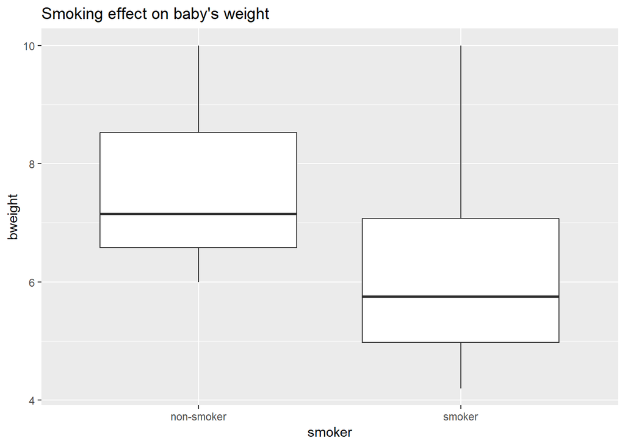

```r
ggplot(Data,aes(factor(smoker),bweight)) + geom_boxplot() + xlab("smoker") + ggtitle("Smoking effect on baby's weight") #there is no outliers
```

```r
head(Data)
```

```
##   headcir length bweight gestation smoker motherage mnocig mheight mppwt
## 1      12     19     4.2        33 smoker        20      7      63   109
## 2      12     18     4.5        35 smoker        41      7      65   125
## 3      12     16     4.7        33 smoker        36     18      66   131
## 4      12     17     4.8        33 smoker        37     17      65   124
## 5      12     16     4.9        34 smoker        28     15      64   139
## 6      13     17     4.9        36 smoker        36     10      64   124
##   fage fedyrs fnocig bined_weight lowbwt     mage35 LowBirthWeight
## 1   20     10     35            5      1 ageunder35            Low
## 2   37     14     25            5      1  ageover35            Low
## 3   19     13     20            5      1  ageover35            Low
## 4   22     13     19            5      1  ageover35            Low
## 5   24     11     17            5      1 ageunder35            Low
## 6   34     15     15            5      1  ageover35            Low
```

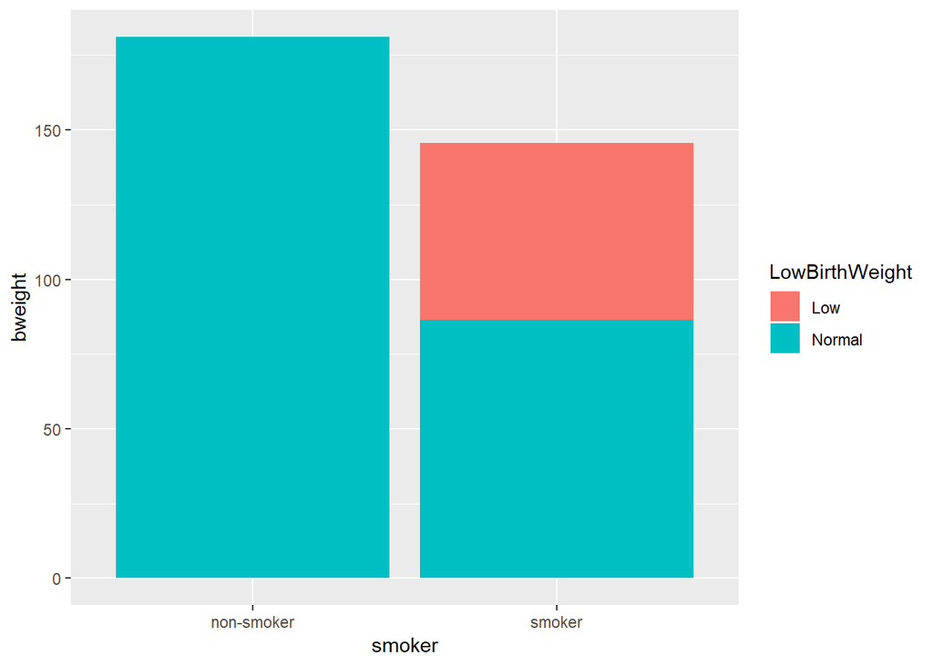

```r
ggplot(Data,aes(x=smoker, y=bweight, fill =LowBirthWeight)) +
  geom_bar(stat = "identity") #in bar_plot we see that only smokers have babies with Low Birth Weight
```

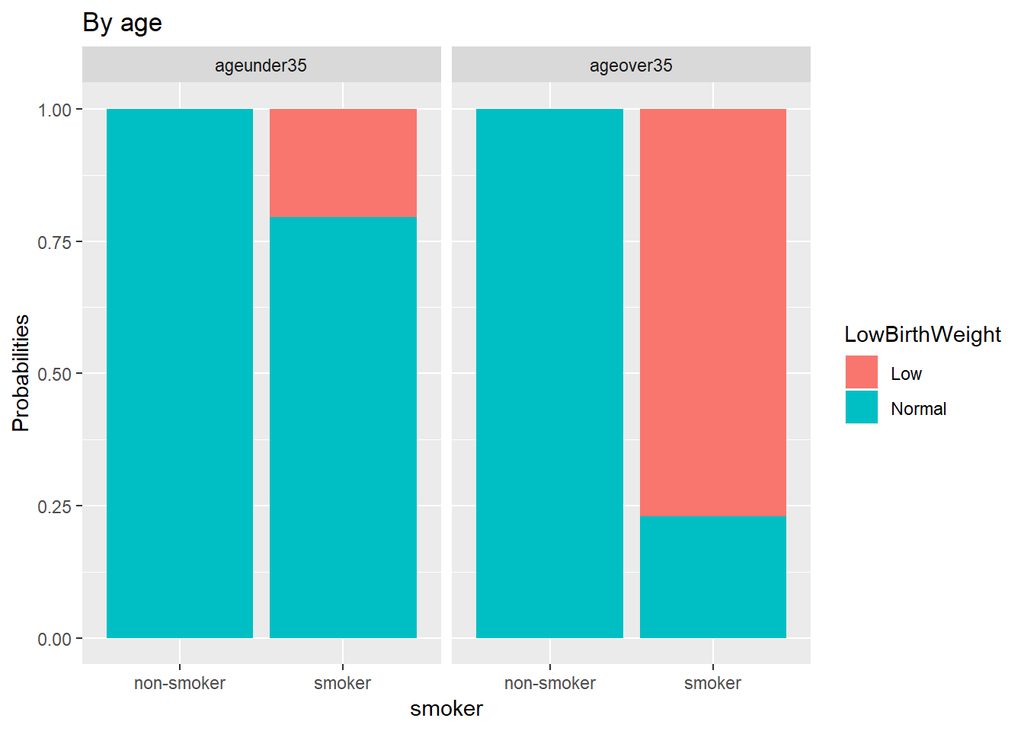

```r
ggplot(Data,aes(x=smoker,y=bweight,fill=LowBirthWeight)) + geom_bar(stat="identity",position='fill') +
  facet_grid(~mage35) + labs(y="Probabilities",title="By age")
```

c. Plot one histogram for a categorical variable. What is the difference between bar graph and histogram?